# Final Models

#### A study of Asian Religious and Biblical Texts Data Set

Adrianna Grudzień, Mateusz Stączek

Data: [archive.ics.uci.edu](https://archive.ics.uci.edu/ml/datasets/A+study+of++Asian+Religious+and+Biblical+Texts)

Related article: [www.researchgate.net](https://www.researchgate.net/publication/338137955_What_do_Asian_Religions_Have_in_Common_An_Unsupervised_Text_Analytics_Exploration)

### Introduction

In this task, there are 8 religious texts, 4 from Asia, 4 Biblical:

- Upanishads,
- Yoga Sutras,
- Buddha Sutras,
- Tao Te Ching,
- Book of Wisdom,
- Book of Proverbs,
- Book of Ecclesiastes,
- Book of Ecclesiasticus.

Each text has been divided into chapters (590 chapters in total) and the goal is to divide these chapters into clusters matching book of origin (or at least divide chapters into 4 religions). This notebook contains choosing the best models and visualizing the results.

### Reading data

```python
import warnings
warnings.filterwarnings('ignore')
import pandas as pd
import matplotlib.pyplot as plt
import seaborn as sns
import numpy as np
from sklearn.manifold import TSNE

from sklearn.decomposition import PCA
from sklearn.cluster import KMeans, AgglomerativeClustering
from sklearn.mixture import GaussianMixture
from sklearn.metrics import silhouette_score, davies_bouldin_score, calinski_harabasz_score
```

Here, we load 2 dataframes. The first one is the original BoW (a Bag of Words - count of each word in each chapter) with 8000+ words. The second dataset was created by us and includes both BoW and some statistical information about each chapter such as:

- chapter length,
- number of sentences,
- average sentence length,
- number of words (without stopwords),
- number of unique words (without stopwords),
- average word length,
- chapter complexity (flesch reading ease),
- positive/negative/neutral tinting of chapter.

```python
# the original dataframe (BoW only)
df_csv = pd.read_csv('AllBooks_baseline_DTM_Unlabelled.csv')
df_csv.drop(index=13, inplace=True) # remove an empty chapter

# our dataframe (scaled)
df_ours = pd.read_csv("Processed_our_dataframe.csv")
```

### PCA

Create more datasets by transforming both datasets with PCA.

```python
pca = PCA(n_components=0.9, whiten=True)
df_csv_pca = pca.fit_transform(df_csv)
df_ours_pca = pca.fit_transform(df_ours)
```

### Some functions

```python
def get_clustering_metric_scores(data,model,metric,n_clusters):
    # if(model.__name__=='GaussianMixture'):
    #     return [metric(data,
    #                 model(n_components=k).fit_predict(data))
    #             for k in n_clusters]
    # else:
    return [metric(data,
                model(k).fit_predict(data))
            for k in n_clusters]

def plot_metrics(data, model,
            metrics=[silhouette_score, davies_bouldin_score, calinski_harabasz_score],
            clusters=list(range(2,11))):

    len_metrics = len(metrics)
    ncols = min(3,len_metrics)
    nrows = len_metrics / ncols
    fig = plt.figure(figsize=[ncols*4,nrows*3])
    for i in range(len_metrics):
        plt.subplot(nrows, ncols, i + 1)
        plt.title(f"{str(metrics[i].__name__).replace('_', ' ')}")
        scores = get_clustering_metric_scores(data, model, metrics[i], clusters)
        plt.plot(clusters, scores)
    plt.show()
```

## Checking metric plots

Warning: too many plots ahead ;p

Datasets:

- data from csv (big BoW),
- data from csv (big BoW) after PCA,
- our data (smaller BoW + statistical info),
- our data (smaller BoW + statistical info) after PCA.

Models tested:

- KMeans,
- Agglomerative clustering,
- Gaussian mixture model.

Metrics:

- silhouette_score (higher is better, -1 to 1),
- davies_bouldin_score (lower is better, 0 to +inf),
- calinski_harabasz_score (look for peaks, a smooth line means "no differences").

### KMeans

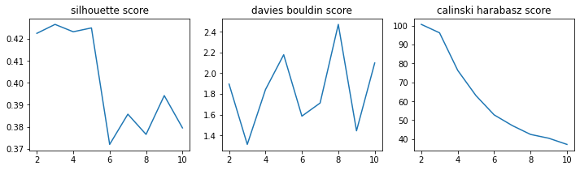

```python
plot_metrics(df_csv, KMeans)
```

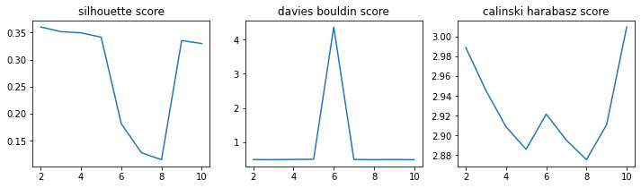

```python
plot_metrics(df_csv_pca, KMeans)
```

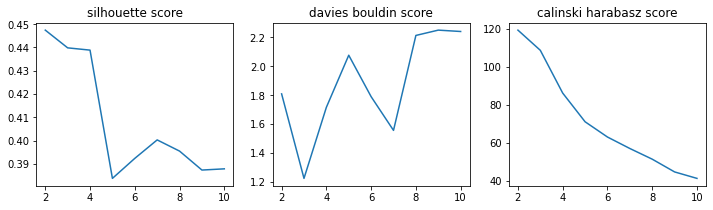

```python
plot_metrics(df_ours, KMeans)
```

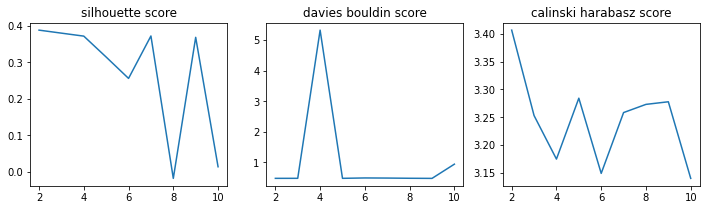

```python
plot_metrics(df_ours_pca, KMeans)
```

When KMeans is used, the best number of clusters we propose is 2 or 3.

### Agglomerative Clustering

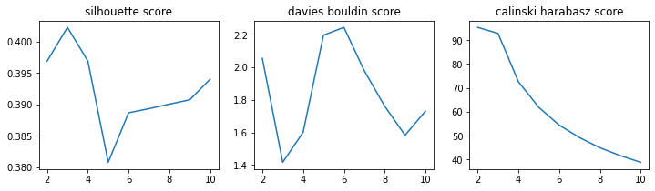

```python
plot_metrics(df_csv, AgglomerativeClustering)
```

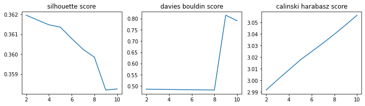

```python
plot_metrics(df_csv_pca, AgglomerativeClustering)
```

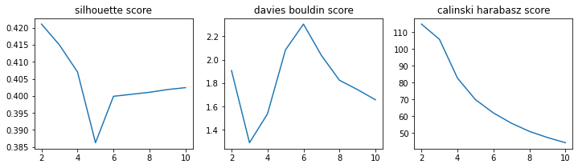

```python
plot_metrics(df_ours, AgglomerativeClustering)
```

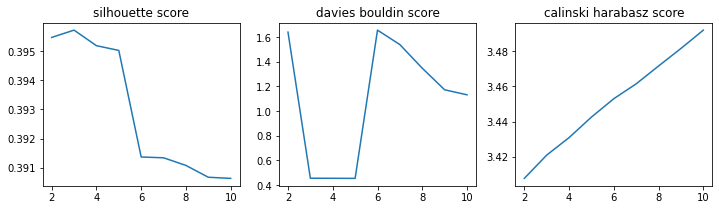

```python
plot_metrics(df_ours_pca, AgglomerativeClustering)
```

When Agglomerative Clustering is used, the best number of clusters we propose is 3.

### Gaussian Mixture Model

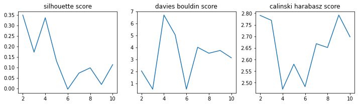

```python
plot_metrics(df_csv_pca, GaussianMixture)
```

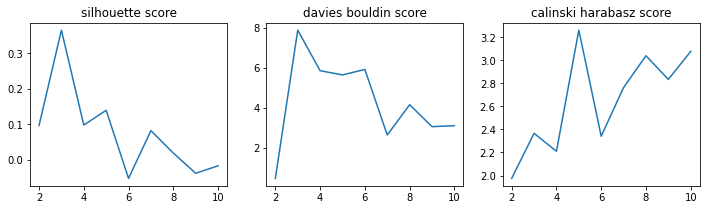

```python
plot_metrics(df_ours_pca, GaussianMixture)
```

When Gaussian Mixture Modeli is used, the best number of clusters we propose is ... It seems like 9.

## Summary

Overall, model selection is equally important as feature engineering. In our opinion, the best way of clustering these 590 chapters into groups is by using KMeans or Agglomerative Clustering with 2 clusters.

What's more, even the knowledge of the original number of clusters in this task did not help recreating the original 8 books from 589 chapters. Instead, the best we could do is to separate chapters from Christian religion from texts originating in eastern religions.

## Visualization of the results

We present 3 visualizations. The first one is a simple KMeans with 2 clusters. Next one is more unexpected - Gaussian Mixture Model with 9 clusters. The last one is Agglomerative clustering for 3 clusters. For each visualization there are 2 scatterplots: one is showing real labels and the other clustering results.

Finally, for each of these 3 clusterings there is a plot showing the percentage of each original label present in each created cluster. In other words, it's the percentage of all chapters from a given book clustered in each cluster for our clustering solutions.

### Preparing labels

```python
labels = pd.read_csv('AllBooks_baseline_DTM_Labelled.csv').iloc[:,0]
del labels[13] # this chapter is empty and has been deleted at the beginning
labels = [x.split('_')[0] for x in labels]

df_labels = pd.DataFrame(labels, columns=['8_labels'])
df_labels['2_labels'] = df_labels['8_labels'].replace({
        'Buddhism' : 'Other',
        'TaoTeChing' : 'Other',
        'Upanishad' : 'Other',
        'YogaSutra' : 'Other',
        'BookOfProverb' : 'Christianity',
        'BookOfEcclesiastes' : 'Christianity',
        'BookOfEccleasiasticus' : 'Christianity',
        'BookOfWisdom' : 'Christianity'
    })
```

#### ... and a few functions

```python
def scatterplot_compare(data, labels_original, labels_predicted):
    df_reduced = PCA(n_components=2, whiten=True).fit_transform(data)

    t1 = pd.DataFrame({'x': df_reduced[:, 0],
                        'y': df_reduced[:, 1],
                        'Original label': labels_original})
    t2 = pd.DataFrame({'x': df_reduced[:, 0],
                        'y': df_reduced[:, 1],
                        'Predicted label': labels_predicted})

    fig = plt.figure(figsize=[9,4])
    plt.subplot(1,2,1)
    plt.title('Original labels')
    sns.scatterplot(data=t1, x='x', y='y', hue='Original label')
    plt.subplot(1,2,2)
    plt.title('Clustering results')
    sns.scatterplot(data=t2, x='x', y='y', hue='Predicted label')
    plt.show()

def get_clusters_percentage(correct_labels, predicted_labels):
    vcounts = correct_labels.value_counts()
    cluster_ids = predicted_labels.unique()
    df_vcounts = pd.DataFrame(columns=['YogaSutra',
                                    'Upanishad',
                                    'TaoTeChing',
                                    'BookOfEccleasiasticus',
                                    'Buddhism',
                                    'BookOfProverb',
                                    'BookOfWisdom',
                                    'BookOfEcclesiastes'])
    for k in cluster_ids:
        df_vcounts = df_vcounts.append(correct_labels[predicted_labels == k].value_counts())
    df_vcounts.index=cluster_ids
    df_vcounts = df_vcounts/vcounts
    df_vcounts.fillna(0, inplace=True)
    return df_vcounts.transpose()

def plot_clusters_barplots(correct_labels, predicted_labels):
    df_percentages = get_clusters_percentage(correct_labels, predicted_labels)
    ncols = len(df_percentages)
    nrows = len(df_percentages.columns)
    fig = plt.figure(figsize=[ncols,nrows*4])
    for i in range(nrows):
        plt.subplot(nrows, 1, i + 1)
        plt.title(f"Book percentages in {i}th predicted cluster")
        tmp = pd.DataFrame(data=[df_percentages.iloc[:,i].index, df_percentages.iloc[:,i]]).transpose()
        tmp.columns = ['Original book', 'Percentage of each book in this cluster']
        tmp
        sns.barplot(data=tmp,
                    x='Original book',
                    y= 'Percentage of each book in this cluster')
        plt.xticks(rotation=70)
        plt.ylim(0,1)
        plt.tick_params(labelbottom=False)
        plt.subplots_adjust(hspace=0.4)
    plt.tick_params(labelbottom=True)
    plt.show()
```

### KMeans with 2 clusters

Good results but Agglomerative Clustering would do better.

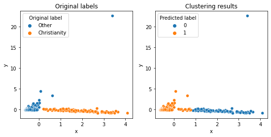

```python
data_for_KMeans = df_ours
df_labels['KMeans_pred_2'] = KMeans(2).fit_predict(data_for_KMeans)

scatterplot_compare(data = data_for_KMeans,
                labels_original = df_labels['2_labels'],
                labels_predicted = df_labels['KMeans_pred_2'])
```

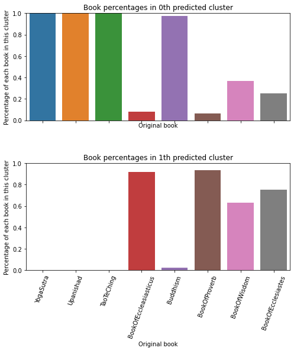

```python
plot_clusters_barplots(df_labels['8_labels'], df_labels['KMeans_pred_2'])
```

### Gaussian Mixture Model with 9 clusters - does it even work?

Nope.

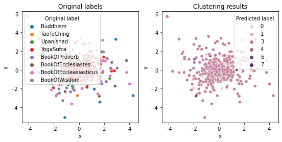

```python
data_for_GMM = df_ours_pca
df_labels['GMM_pred_9'] = GaussianMixture(9).fit_predict(data_for_GMM)

scatterplot_compare(data = data_for_GMM,
                labels_original = df_labels['8_labels'],
                labels_predicted = df_labels['GMM_pred_9'])
```

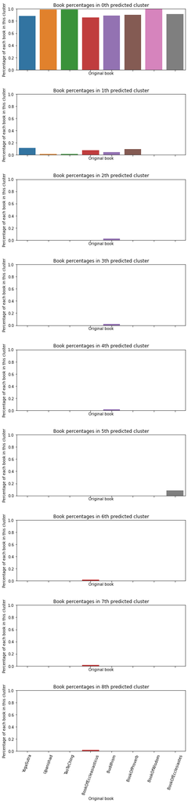

```python
plot_clusters_barplots(df_labels['8_labels'], df_labels['GMM_pred_9'])
```

### Agglomerative Clustering for 3 clusters

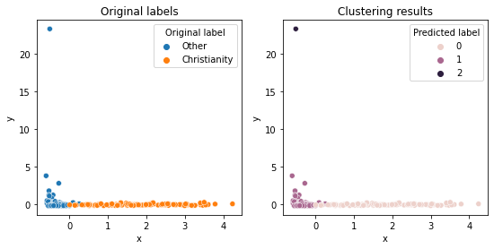

```python
data_for_AGG = df_csv
df_labels['AGG_pred_3'] = AgglomerativeClustering(3).fit_predict(data_for_AGG)

scatterplot_compare(data = data_for_AGG,
                labels_original = df_labels['2_labels'],
                labels_predicted = df_labels['AGG_pred_3'])
```

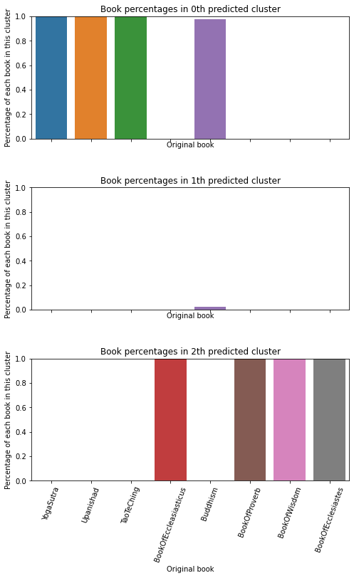

```python
plot_clusters_barplots(df_labels['8_labels'], df_labels['AGG_pred_3'])
```

# Final thoughts

We can divide all data into 2 clusters that separate eastern religions' texts from Christian texts.

# Bonus - plots for random numbers of cluetrs ;)

Spoiler: Agglomerative Clustering for the original data with no feature engineering and with 2 clusters divides christian vs non - christian texts perfectly.

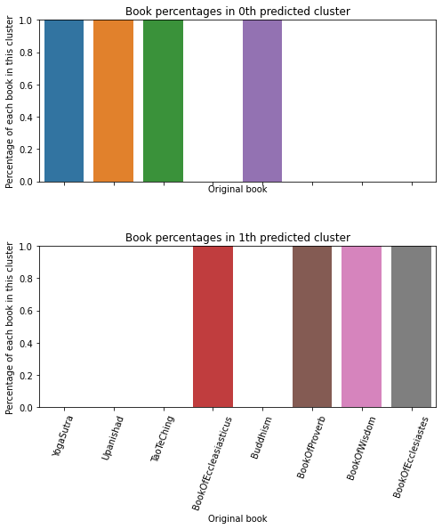

```python
data_for_AGG = df_csv
df_labels['AGG_pred_2'] = AgglomerativeClustering(2).fit_predict(data_for_AGG)
plot_clusters_barplots(df_labels['8_labels'], df_labels['AGG_pred_2'])
```

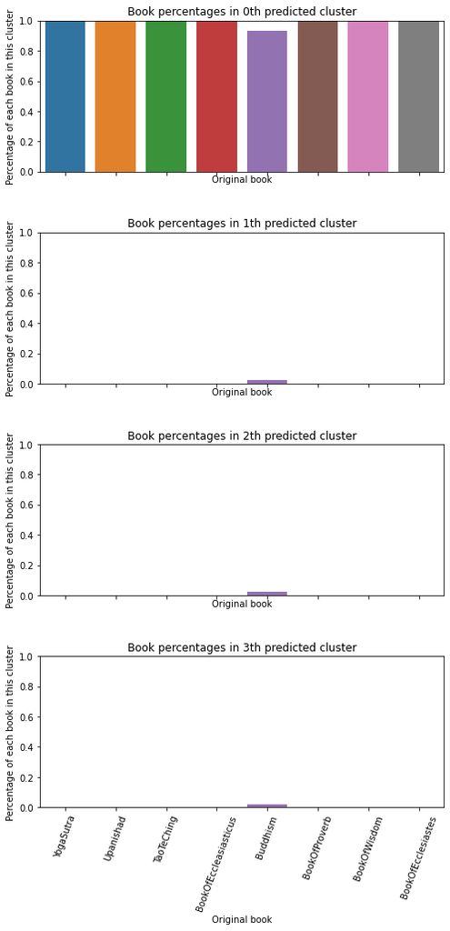

```python
# pca psuje
data_for_AGG = df_ours_pca
df_labels['AGG_pred_2'] = AgglomerativeClustering(4).fit_predict(data_for_AGG)
plot_clusters_barplots(df_labels['8_labels'], df_labels['AGG_pred_2'])
```

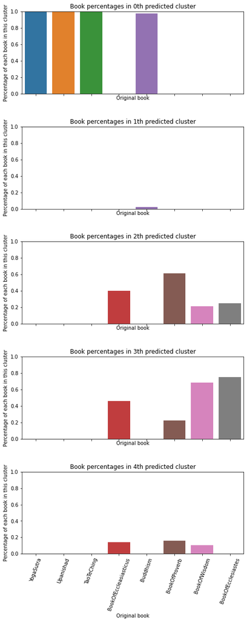

```python
data_for_AGG = df_csv
df_labels['AGG_pred_5'] = AgglomerativeClustering(5).fit_predict(data_for_AGG)
plot_clusters_barplots(df_labels['8_labels'], df_labels['AGG_pred_5'])
```

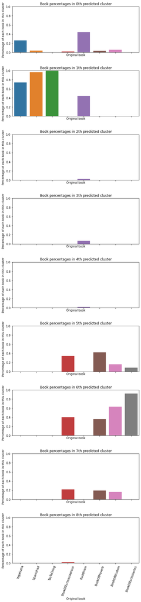

```python
data_for_KM = df_ours
df_labels['KM_pred_5'] = KMeans(9).fit_predict(data_for_KM)
plot_clusters_barplots(df_labels['8_labels'], df_labels['KM_pred_5'])
```

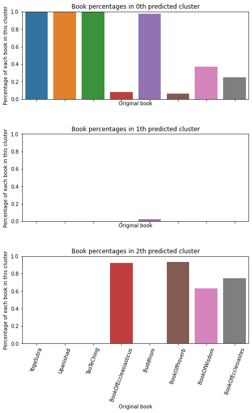

```python
data = df_ours
df_labels['GMM_pred_3'] = GaussianMixture(3).fit_predict(data)
plot_clusters_barplots(df_labels['8_labels'], df_labels['GMM_pred_3'])
```

[figure not shown]

Created in Deepnote